# Estudio LEGO

Daniela Corbetta

## Intro

La empresa LEGO es conocida a nivel global y es al día de hoy una de las marcas de juguetes más vendida. No debe extrañarnos que existan estudios, internos e externos a la empresa, sobre la evolución de su producción y venta, bajo distintas perspectivas.

El dataset objeto de estudio recoge varios detalles de interés para la optimización y el estudio de los recursos LEGO: desde los precios hasta las piezas, desde los temas que caracterizan el juegos hasta su disponibilidad en el mercado; sin embargo, ya a primera vista, resulta claro que se trata de un conjunto de datos que presenta varios defectos: la ausencia de un número significativo de datos; la recopilación no procesada de algunas variables; variables no confiables del todo por la presencia de valores anómalos etc.

Por ello, para poder aprovechar la información y analizar el conjunto, es necesario seguir unas pautas organizadas y así proceder al análisis:  
1. Inspeccionar el dataset y formular unas preguntas iniciales  
2. Limpiar y procesar el dataset según los objetivos de respuesta  
3. Analizar el conjunto mediante distintos enfoques y sacar conclusiones

## 1. Preparación de los recursos

```r
# cargo las librerías que sirven para procesar el conjunto de datos
suppressPackageStartupMessages( {
  library(tidytable)    # para visualizar tablas de datos de forma clara y concisa
  library(dplyr)        # para manipular datos
  library(data.table)   # para manipular datos
  library(ggplot2)      # para crear visualizaciones de datos
  library(formattable)  # para mejorar la visualización de las tablas
  library(skimr)        # para realizar cálculos básicos
  library(tidyverse)    # para varias funciones de procesamiento de dataset
  library(patchwork)    # para mejorar las visualizaciones de datos
  library(plyr)         # para manipular datos
  library(VIM)          # para visualizar e imputar valores faltantes
  library(ggpubr)
})
```

```r
# importo y leo el archivo CSV
datos <- read.csv("~/lego_population_cof.csv")

# muestro las primeras filas del dataframe para verificar que se haya cargado correctamente
head(datos)
```

```
##   X Item_Number Set_Name Amazon_Price Year Pages unique_pieces Theme Pieces
## 1 1           -     <NA>                NA    NA            NA  <NA>     NA
## 2 2           -     <NA>                NA    NA            NA  <NA>     NA
## 3 3           -     <NA>            -   NA    NA            NA  <NA>     NA
## 4 4           -     <NA>            -   NA    NA            NA  <NA>     NA
## 5 5           -     <NA>       €50.90   NA    NA            NA  <NA>     NA
## 6 6           -     <NA>       €45.04   NA    NA            NA  <NA>     NA
##   Price    Ages Minifigures Packaging Weight Availability Size
## 1    NA Ages_NA          NA      <NA>   <NA>         <NA> <NA>
## 2    NA Ages_NA          NA      <NA>   <NA>         <NA> <NA>
## 3    NA Ages_NA          NA      <NA>   <NA>         <NA> <NA>
## 4    NA Ages_NA          NA      <NA>   <NA>         <NA> <NA>
## 5    NA Ages_NA          NA      <NA>   <NA>         <NA> <NA>
## 6    NA Ages_NA          NA      <NA>   <NA>         <NA> <NA>
```

Se recoge a continuación una descripción de cada variable presente en el dataset cargado.  
1. La columna **X** parece indicar solo el número de fila, por lo tanto, no proporciona información de interés  
2. **Item_Number** parece referirse al número de serie; sin embargo, hay valores cuyo formato no corresponde a la mayoría. Sobre esos es necesario realizar algun tratamiento.  
3. La variable **Set_Name** parece indicar el nombre de la pieza  
4. La variable **Amazon_Price** nos indica el precio en Amazon: puede ser de utilidad para investigar relaciones  
5. **Year** parece indicar el año de salida de la pieza  
6. La columna **Pages** está vacía, por lo tanto, se procederá a eliminarla.  
7. En **unique_pieces** se indica el número total de Elementos LEGO únicos, es decir especiales para ese productos.  
8. La columna **Theme**, que recoge la línea del producto, puede ser de especial interés para la búsqueda de relaciones entre variables.  
9. La variable **Pieces** también es relevante para llegar a conclusiones  
10. Al igual que la columa **Pages**, la de **Price** está vacía y se procederá a eliminarla.  
11. En **Ages** nos encontramos con la edad adecuada para el tipo de producto: la variable requiere limpieza puesto que los NAs están reflejados en formato character y hay rangos de edad que hacen que la variable sea categorica.  
12. La columna**Minifigures** recoge la cantidad de las famosas piezas minifiguras presentes en ese producto.  
13. La columna de **Packaging** nos proporciona información acerca de cómo está confeccionado el prodcutoy puede ser de interés para la exploración.  
14. La variable **Weight** recoge el peso final del producto, tanto en Kg como en lb. En este sentido, se aplicará un tratamiento de limpieza para poder analizar esta variable.  
15. **Availability** se refiere a la disponibilidad del producto: en web, en tiendas, en tiendas pero limitadas, no se vende etc.  
16.La variable **Size** nos indica el tamaño del producto.

En general, hay muchas líneas vacías o con uno o dos datos, lo cual, en principio, impide un análisis exhaustivo.

### 1.1. Inspección inicial

Para tener una idea de los datos que vamos a tratar, se aplica la función `skim`: así pues, se puede valorar el tipo de variable, su completitud y algunas medidas de tendencias para las variables númericas.

```r
formattable(skim(datos))
```

| skim_type | skim_variable | n_missing | complete_rate | character.min | character.max | character.empty | character.n_unique | character.whitespace | logical.mean | logical.count | numeric.mean | numeric.sd | numeric.p0 | numeric.p25 | numeric.p50 | numeric.p75 | numeric.p100 | numeric.hist |
| --- | --- | --- | --- | --- | --- | --- | --- | --- | --- | --- | --- | --- | --- | --- | --- | --- | --- | --- |
| character | Item_Number | 0 | 1.0000000 | 1 | 8 | 0 | 1922 | 0 | NA | NA | NA | NA | NA | NA | NA | NA | NA | NA |
| character | Set_Name | 974 | 0.5778067 | 2 | 66 | 0 | 1297 | 0 | NA | NA | NA | NA | NA | NA | NA | NA | NA | NA |
| character | Amazon_Price | 1333 | 0.4221933 | 0 | 8 | 244 | 372 | 0 | NA | NA | NA | NA | NA | NA | NA | NA | NA | NA |
| character | Theme | 977 | 0.5765063 | 3 | 24 | 0 | 47 | 0 | NA | NA | NA | NA | NA | NA | NA | NA | NA | NA |
| character | Ages | 0 | 1.0000000 | 7 | 11 | 0 | 35 | 0 | NA | NA | NA | NA | NA | NA | NA | NA | NA | NA |
| character | Packaging | 1014 | 0.5604681 | 3 | 21 | 0 | 12 | 0 | NA | NA | NA | NA | NA | NA | NA | NA | NA | NA |
| character | Weight | 1616 | 0.2995232 | 10 | 18 | 0 | 246 | 0 | NA | NA | NA | NA | NA | NA | NA | NA | NA | NA |
| character | Availability | 1101 | 0.5227568 | 6 | 18 | 0 | 7 | 0 | NA | NA | NA | NA | NA | NA | NA | NA | NA | NA |
| character | Size | 974 | 0.5778067 | 5 | 5 | 0 | 2 | 0 | NA | NA | NA | NA | NA | NA | NA | NA | NA | NA |
| logical | Pages | 2307 | 0.0000000 | NA | NA | NA | NA | NA | NaN | : | NA | NA | NA | NA | NA | NA | NA | NA |
| logical | Price | 2307 | 0.0000000 | NA | NA | NA | NA | NA | NaN | : | NA | NA | NA | NA | NA | NA | NA | NA |
| numeric | X | 0 | 1.0000000 | NA | NA | NA | NA | NA | NA | NA | 1154.00000 | 666.1178574 | 1 | 577.5 | 1154 | 1730.5 | 2307 | ▇▇▇▇▇ |
| numeric | Year | 974 | 0.5778067 | NA | NA | NA | NA | NA | NA | NA | 2019.00750 | 0.8246962 | 2018 | 2018.0 | 2019 | 2020.0 | 2020 | ▇▁▇▁▇ |
| numeric | unique_pieces | 1008 | 0.5630689 | NA | NA | NA | NA | NA | NA | NA | 118.59276 | 112.7669972 | 1 | 39.0 | 83 | 164.0 | 1067 | ▇▁▁▁▁ |
| numeric | Pieces | 986 | 0.5726051 | NA | NA | NA | NA | NA | NA | NA | 397.04164 | 652.6919100 | 1 | 70.0 | 193 | 456.0 | 9036 | ▇▁▁▁▁ |
| numeric | Minifigures | 1398 | 0.3940182 | NA | NA | NA | NA | NA | NA | NA | 3.20242 | 2.7643806 | 1 | 1.0 | 3 | 4.0 | 28 | ▇▁▁▁▁ |

De la tabla anterior se puede observar:  
1. Las columnas `Price` y `Pages`están vacías  
2. La columna `Ages` parece completa, así como la de `Item_Number`  
3. Hay 47 temáticas distintas para la variable `Theme`. Esta variable puede revelarse importante para encontrar relaciones.  
4. Existen 12 tipos de empaquetado.  
5. Existen 2 tipos de tamaño.  
6. Existen 7 tipos de disponibilidad para comprar el producto.  
7. Las distribuciones de las piezas, tanto totales como únicas, no sigue una normal: los datos parecen muy dispersos  
8. En cuanto a la variable de `Year`, el dataset recoge la información de 3 años: 2018, 2019, 2020.  
9. La variable `Set_Name` muestra una variabilidad muy alta, véase la columna `character.n_unique`: seguramente esta variable no sea de utilidad.

Desconocemos si el dataset está construido sobre lo vendido o lo que está en comercio, pero vamos a suponer que se trata de un registro de los productos vendidos en cierto intervalo de tiempo.

**Preguntas de interés**

- Cuánta diferencia hay entre los temas que se han vendido entre 2018 y 2020?
- Existe alguna diferencia significativa entre un tema y otro?
- Para qué edad es adecuado cada tema?
- Hay una relación entre el número de piezas y el tema?
- Hay una relación entre el número de piezas y las piezas únicas?
- Ha habido una evoluación con respecto a las ventas entre 2018 y 2020?
- Hay una relación entre el número de piezas y el peso del juego?

## 2. Limpieza de datos

Para poder trabajar de forma ágil con el dataset, se aplican unos procesos de limpieza.

```r
# elimino del dataframe las columnas que sé que están completamente vacías o que no aportan información
delete_columns <- c("Price","Pages","X")
datosNew <- datos[ , !(names(datos) %in% delete_columns)]
# head(datosNew)
```

```r
# creo un nuevo dataset aplicando cambios significativos a las variables
datosNew <- datosNew %>%

  # elimino los Ages_NA para que quede el valor NA
  mutate(Ages = replace(Ages, Ages == "Ages_NA", NA_character_)) %>%

  # elimino el texto Ages_ para quedarme solo con los numeros
  mutate(Ages = str_replace(Ages, "Ages_", "")) %>%

  # uniformo el formato con una edad a partir de la cual es juego es apto
  mutate(Ages = str_replace(Ages, " - \\d+", "+")) %>%

  # elimino la medida de peso y la conversión a lb
  mutate(Weight = str_replace(Weight, "Kg .+", "")) %>%

  # elimino el simbolo de € en Amazon_Price para quedarme solo con el valor
  mutate(Amazon_Price = str_replace(Amazon_Price, "€", "")) %>%

  # elimino el guión para que se quede vacío en Amazon_Price
  mutate(Amazon_Price = str_replace(Amazon_Price, "-", "")) %>%

  # convierto la columna Year, Theme, Packaging, Availability y Size a factor
  mutate(Year = as.factor(Year),
         Theme = as.factor(Theme),
         Packaging = as.factor(Packaging),
         Availability = as.factor(Availability),
         Size = as.factor(Size))

head(datosNew)
```

```
##   Item_Number Set_Name Amazon_Price Year unique_pieces Theme Pieces Ages
## 1           -     <NA>              <NA>            NA  <NA>     NA <NA>
## 2           -     <NA>              <NA>            NA  <NA>     NA <NA>
## 3           -     <NA>              <NA>            NA  <NA>     NA <NA>
## 4           -     <NA>              <NA>            NA  <NA>     NA <NA>
## 5           -     <NA>        50.90 <NA>            NA  <NA>     NA <NA>
## 6           -     <NA>        45.04 <NA>            NA  <NA>     NA <NA>
##   Minifigures Packaging Weight Availability Size
## 1          NA      <NA>   <NA>         <NA> <NA>
## 2          NA      <NA>   <NA>         <NA> <NA>
## 3          NA      <NA>   <NA>         <NA> <NA>
## 4          NA      <NA>   <NA>         <NA> <NA>
## 5          NA      <NA>   <NA>         <NA> <NA>
## 6          NA      <NA>   <NA>         <NA> <NA>
```

A pesar de que puede no ser el enfoque más correcto, para responder a las preguntas iniciales, en la columna `Ages` se ha optado por uniformar el dato con la edad mínima aconsejada para el juego.

```r
# convierto la variable de peso a númerica
datosNew <- datosNew %>%
  mutate(Weight = as.numeric(Weight))

head(datosNew)
```

```
##   Item_Number Set_Name Amazon_Price Year unique_pieces Theme Pieces Ages
## 1           -     <NA>              <NA>            NA  <NA>     NA <NA>
## 2           -     <NA>              <NA>            NA  <NA>     NA <NA>
## 3           -     <NA>              <NA>            NA  <NA>     NA <NA>
## 4           -     <NA>              <NA>            NA  <NA>     NA <NA>
## 5           -     <NA>        50.90 <NA>            NA  <NA>     NA <NA>
## 6           -     <NA>        45.04 <NA>            NA  <NA>     NA <NA>
##   Minifigures Packaging Weight Availability Size
## 1          NA      <NA>     NA         <NA> <NA>
## 2          NA      <NA>     NA         <NA> <NA>
## 3          NA      <NA>     NA         <NA> <NA>
## 4          NA      <NA>     NA         <NA> <NA>
## 5          NA      <NA>     NA         <NA> <NA>
## 6          NA      <NA>     NA         <NA> <NA>
```

```r
# produzco una variable temporal para poder analizar los valores faltantes
dfSkim <- skim(datosNew)
```

```r
valores_faltantes <- dfSkim %>%

  # aplico la función mutate para obtener el porcentaje redondeado
  mutate(n_missing_perc = 100 * round(1 - complete_rate, 3)) %>%

  # elijo las columnas que me interesa mostrar
  select(skim_variable, skim_type, n_missing, n_missing_perc) %>%

  # ordeno según las columnas skim_type, n_missing
  arrange(skim_type, n_missing)

# uso la función formattable para presentar la tabla de forma ordenada
formattable(valores_faltantes)
```

| skim_variable | skim_type | n_missing | n_missing_perc |
| --- | --- | --- | --- |
| Item_Number | character | 0 | 0.0 |
| Set_Name | character | 974 | 42.2 |
| Ages | character | 1332 | 57.7 |
| Amazon_Price | character | 1333 | 57.8 |
| Year | factor | 974 | 42.2 |
| Size | factor | 974 | 42.2 |
| Theme | factor | 977 | 42.3 |
| Packaging | factor | 1014 | 44.0 |
| Availability | factor | 1101 | 47.7 |
| Pieces | numeric | 986 | 42.7 |
| unique_pieces | numeric | 1008 | 43.7 |
| Minifigures | numeric | 1398 | 60.6 |
| Weight | numeric | 1616 | 70.0 |

Habida cuenta de tantos datos faltantes, y que las líneas más completas suelen ser aquellas donde aparece el dato de la variable `Theme`, se procede a eliminar todas aquellas líneas donde `Theme` está vacía.

```r
# elimino donde no existe valor para la variable Theme
datosReduced <- datosNew %>%
  filter(!is.na(Theme))
```

### 2.1 Missing values

De nuevo, se procede al análisis de los valores faltantes con el nuevo dataset, para así poder analizar con más profundidad la distribución, el comportamiento y las relaciones entre variables.

```r
# creo una variable temporal para ver el estado de los valores faltantes con el nuevo dataset
dfSkim2 <- skim(datosReduced)
```

```r
valores_faltantes <- dfSkim2 %>%

  # aplico la función mutate para obtener el porcentaje redondeado
  mutate(n_missing_perc = 100 * round(1 - complete_rate, 3)) %>%

  # elijo las columnas que me interesa mostrar
  select(skim_variable, skim_type, n_missing, n_missing_perc) %>%

  # ordeno según las columnas skim_type, n_missing
  arrange(skim_type, n_missing)

# uso la función formattable para presentar la tabla de forma ordenada
formattable(valores_faltantes)
```

| skim_variable | skim_type | n_missing | n_missing_perc |
| --- | --- | --- | --- |
| Item_Number | character | 0 | 0.0 |
| Set_Name | character | 0 | 0.0 |
| Ages | character | 355 | 26.7 |
| Amazon_Price | character | 1330 | 100.0 |
| Year | factor | 0 | 0.0 |
| Theme | factor | 0 | 0.0 |
| Size | factor | 0 | 0.0 |
| Packaging | factor | 37 | 2.8 |
| Availability | factor | 124 | 9.3 |
| Pieces | numeric | 9 | 0.7 |
| unique_pieces | numeric | 31 | 2.3 |
| Minifigures | numeric | 421 | 31.7 |
| Weight | numeric | 639 | 48.0 |

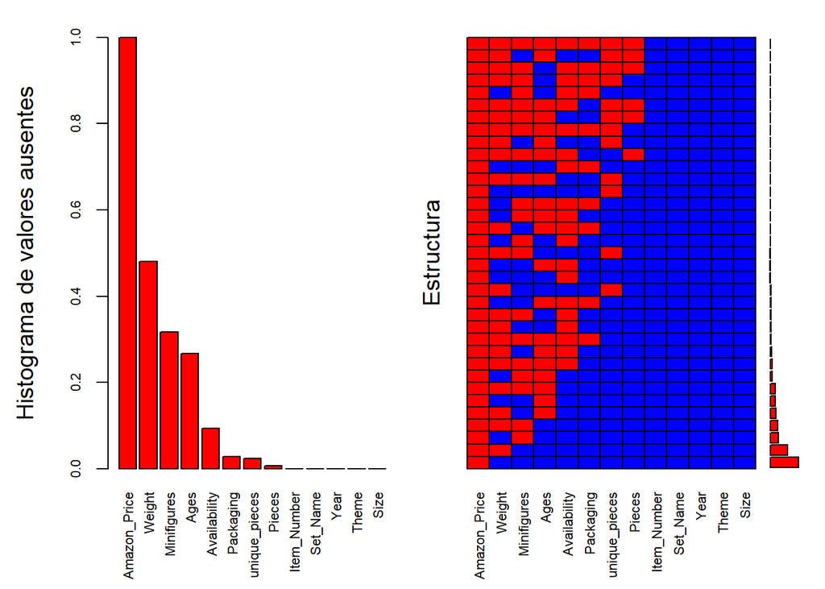

```
##
##  Variables sorted by number of missings:
##       Variable       Count
##   Amazon_Price 1.000000000
##         Weight 0.480451128
##    Minifigures 0.316541353
##           Ages 0.266917293
##   Availability 0.093233083
##      Packaging 0.027819549
##  unique_pieces 0.023308271
##         Pieces 0.006766917
##    Item_Number 0.000000000
##       Set_Name 0.000000000
##           Year 0.000000000
##          Theme 0.000000000
##           Size 0.000000000
```

```r
# grafico la distribución de los valores faltantes
aggr_plot <- aggr(datosReduced,col=c('blue','red'),
                  numbers =TRUE,
                  sortVars =TRUE,
                  labels =names(datosReduced),
                  cex.axis =.7,
                  gap =3,
                  ylab =c("Histograma de valores ausentes","Estructura"))
```

De la tabla anterior y del gráfico anterior, se puede observar que:  
1. Hay un porcentaje significativos de valores faltantes en `Ages`, `Minifigures` y `Weight`: imputar esos valores puede que no sea la alternativa más oportuna siempre; sin embargo, en nuestro caso de estudio, se procede a imputar según estos criterios:  
1.1. Teniendo en cuenta que la variable `Theme` en cierto modo también nos proporciona información sobre la edad target, imputamos la edad según la moda de cada tema. 1.2. Suponiendo que hay una correlación entre el número de piezas y el peso y las minifiguras, imputamos ambas con una regresión lineal, `Pieces` como variable independiente  
1.3. En cuanto `Packaging` y `Availability`, siendo el porcentaje relativamente más bajo, se opta por imputar la moda entre todo el conjunto (sin agrupar por tema). 2. La columna `Amazon_Price` está completamente vacía, por lo tanto se puede eliminar.

### 2.2. Imputación de valores ausentes

```r
# función para obtener la moda de una variable categorica
mode_func <- function(x) {
  if (length(unique(x)) == 1) {
    return(unique(x))
  } else {
    tab <- table(x)
    return(names(tab)[tab == max(tab)])
  }
}

# función para obtener una tabla de frecuencia y así imputar la moda
moda <- function(variable) {
  frecuencias <- table(variable)
  moda <- names(which.max(frecuencias))
  if (length(which.max(frecuencias)) > 1) {
    moda <- NULL
  }
  return(moda)
}

# función para imputar la moda según la clase de la variable
imputar_moda <- function(dataframe, columna) {

  # calculo la moda en toda la variable
  moda_columna <- moda(dataframe[[columna]])

  # convierto la moda según la clase de la variable
  tipo_columna <- class(dataframe[[columna]][1])
  if (tipo_columna == "factor") {
    moda_columna <- factor(moda_columna)
  } else if (tipo_columna != "numeric") {
    moda_columna <- as.character(moda_columna)
  }

  # imputar los valores ausentes
  dataframe[[columna]][is.na(dataframe[[columna]])] <- moda_columna

  return(dataframe)
}
```

```r
datosReduced <- datosReduced %>%

  # agrupo la variable Theme
  group_by(Theme) %>%

  # imputo Ages
  mutate(Ages = ifelse(is.na(Ages), mode_func(Ages), Ages)) %>%

  # imputo Pieces
  mutate(Pieces = ifelse(is.na(Pieces), round(mean(Pieces, na.rm = TRUE), 0), Pieces)) %>%

  # imputo unique_pieces
  mutate(unique_pieces = ifelse(is.na(unique_pieces), round(mean(unique_pieces, na.rm = TRUE), 0), unique_pieces)) %>%

  ungroup()

datosReduced <- datosReduced %>%

  # imputo Packaging
  imputar_moda(., "Packaging") %>%

  # imputo Availability
  imputar_moda(., "Availability") %>%

  # elimino la columna Amazon_Price
  select(-Amazon_Price) %>%

  # convierto Ages a factor
  mutate(Ages = as.factor(Ages))
```

```r
# imputo los valores ausentes de Weight con regresión lineal
modelo <- lm(Weight ~ Pieces, data = datosReduced)
peso_imputado <- predict(modelo, datosReduced)

# reemplazo los valores Na en el original
datosReduced$Weight[is.na(datosReduced$Weight)] <- peso_imputado
datosReduced$Weight <- round(datosReduced$Weight, 2)
```

```r
# imputo los valores ausentes de Minifigures con regresión lineal
modelo <- lm(Minifigures ~ Pieces, data = datosReduced)
minifiguras_imputado <- predict(modelo, datosReduced)

# reemplazo los valores Na en el original
datosReduced$Minifigures[is.na(datosReduced$Minifigures)] <- minifiguras_imputado
datosReduced$Minifigures <- round(datosReduced$Minifigures, 0)
```

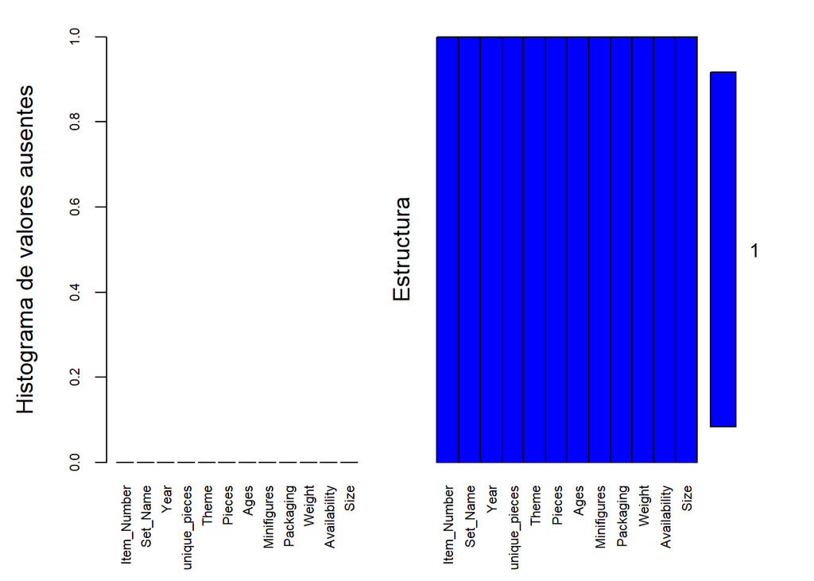

```
##
##  Variables sorted by number of missings:
##       Variable Count
##    Item_Number     0
##       Set_Name     0
##           Year     0
##  unique_pieces     0
##          Theme     0
##         Pieces     0
##           Ages     0
##    Minifigures     0
##      Packaging     0
##         Weight     0
##   Availability     0
##           Size     0
```

```r
# vuelvo a obtener la tabla y a graficar la distribución de los valores faltantes para comprobar que no tengo
aggr_plot <- aggr(datosReduced,col=c('blue','red'),
                  numbers =TRUE,
                  sortVars =TRUE,
                  labels =names(datosReduced),
                  cex.axis =.7,
                  gap =3,
                  ylab =c("Histograma de valores ausentes","Estructura"))
```

```r
formattable(skim(datosReduced))
```

| skim_type | skim_variable | n_missing | complete_rate | character.min | character.max | character.empty | character.n_unique | character.whitespace | factor.ordered | factor.n_unique | factor.top_counts | numeric.mean | numeric.sd | numeric.p0 | numeric.p25 | numeric.p50 | numeric.p75 | numeric.p100 | numeric.hist |
| --- | --- | --- | --- | --- | --- | --- | --- | --- | --- | --- | --- | --- | --- | --- | --- | --- | --- | --- | --- |
| character | Item_Number | 0 | 1 | 5 | 7 | 0 | 1330 | 0 | NA | NA | NA | NA | NA | NA | NA | NA | NA | NA | NA |
| character | Set_Name | 0 | 1 | 2 | 66 | 0 | 1294 | 0 | NA | NA | NA | NA | NA | NA | NA | NA | NA | NA | NA |
| factor | Year | 0 | 1 | NA | NA | NA | NA | NA | FALSE | 3 | 202: 458, 201: 446, 201: 426 | NA | NA | NA | NA | NA | NA | NA | NA |
| factor | Theme | 0 | 1 | NA | NA | NA | NA | NA | FALSE | 47 | Sta: 123, Cit: 120, Fri: 112, Nin: 90 | NA | NA | NA | NA | NA | NA | NA | NA |
| factor | Ages | 0 | 1 | NA | NA | NA | NA | NA | FALSE | 15 | 6+: 307, 7+: 249, 8+: 201, 5+: 147 | NA | NA | NA | NA | NA | NA | NA | NA |
| factor | Packaging | 0 | 1 | NA | NA | NA | NA | NA | FALSE | 12 | Box: 1088, Pol: 169, Foi: 22, Pla: 13 | NA | NA | NA | NA | NA | NA | NA | NA |
| factor | Availability | 0 | 1 | NA | NA | NA | NA | NA | FALSE | 7 | Ret: 989, LEG: 168, Ret: 103, Not: 28 | NA | NA | NA | NA | NA | NA | NA | NA |
| factor | Size | 0 | 1 | NA | NA | NA | NA | NA | FALSE | 2 | Sma: 1259, Lar: 71 | NA | NA | NA | NA | NA | NA | NA | NA |
| numeric | unique_pieces | 0 | 1 | NA | NA | NA | NA | NA | NA | NA | NA | 117.653383 | 111.8006503 | 1 | 39.00 | 82.00 | 162.75 | 1067.00 | ▇▁▁▁▁ |
| numeric | Pieces | 0 | 1 | NA | NA | NA | NA | NA | NA | NA | NA | 395.996992 | 650.6269096 | 1 | 71.25 | 193.00 | 454.00 | 9036.00 | ▇▁▁▁▁ |
| numeric | Minifigures | 0 | 1 | NA | NA | NA | NA | NA | NA | NA | NA | 3.115038 | 2.5807354 | 1 | 2.00 | 2.00 | 4.00 | 28.00 | ▇▁▁▁▁ |
| numeric | Weight | 0 | 1 | NA | NA | NA | NA | NA | NA | NA | NA | 0.607015 | 0.9104783 | 0 | 0.17 | 0.33 | 0.67 | 12.71 | ▇▁▁▁▁ |

## 3. Análisis univariante

### 3.1 Por Tema

El análisis cuantitativo inicial se centra en la variable `Theme`, que hace referencia al tema de juego: se trata de un análisis de frecuencia.

Se construye una tabla de frecuencia según los distintos temas.

```r
setDT(datosReduced)
tableTematicas <-datosReduced[ ,.N, by = "Theme"]
setorder(tableTematicas, -N)
formattable(tableTematicas)
```

| Theme | N |
| --- | --- |
| Star Wars | 123 |
| City | 120 |
| Friends | 112 |
| Ninjago | 90 |
| Duplo | 71 |
| BrickHeadz | 67 |
| Marvel Super Heroes | 57 |
| Promotional | 55 |
| Disney | 48 |
| Creator | 48 |
| Technic | 42 |
| The LEGO Movie 2 | 32 |
| DC Comics Super Heroes | 31 |
| Harry Potter | 30 |
| Education | 29 |
| Minecraft | 28 |
| Miscellaneous | 27 |
| Classic | 25 |
| Hidden Side | 23 |
| Jurassic World | 20 |
| Super Mario | 20 |
| Seasonal | 20 |
| Dots | 19 |
| Juniors | 18 |
| Speed Champions | 18 |
| Ideas | 16 |
| Creator Expert | 13 |
| Architecture | 13 |
| Monkie Kid | 13 |
| Collectable Minifigures | 11 |
| Powered Up | 10 |
| Unikitty | 9 |
| Trolls World Tour | 9 |
| Xtra | 9 |
| Overwatch | 9 |
| The LEGO Batman Movie | 7 |
| Elves | 7 |
| Nexo Knights | 6 |
| Icons | 5 |
| Art | 4 |
| Brick Sketches | 4 |
| FORMA | 4 |
| Mindstorms | 2 |
| The Powerpuff Girls | 2 |
| Minions: The Rise of Gru | 2 |
| The LEGO Ninjago Movie | 1 |
| Stranger Things | 1 |

Se puede notar que hay mucha disparidad entre los más y menos vendidos. **Star Wars, City, Friends** y **Ninjago** encabezan el ranking con diferencia. Se opta por mostrar solo los temas que tiene más de 20 productos.

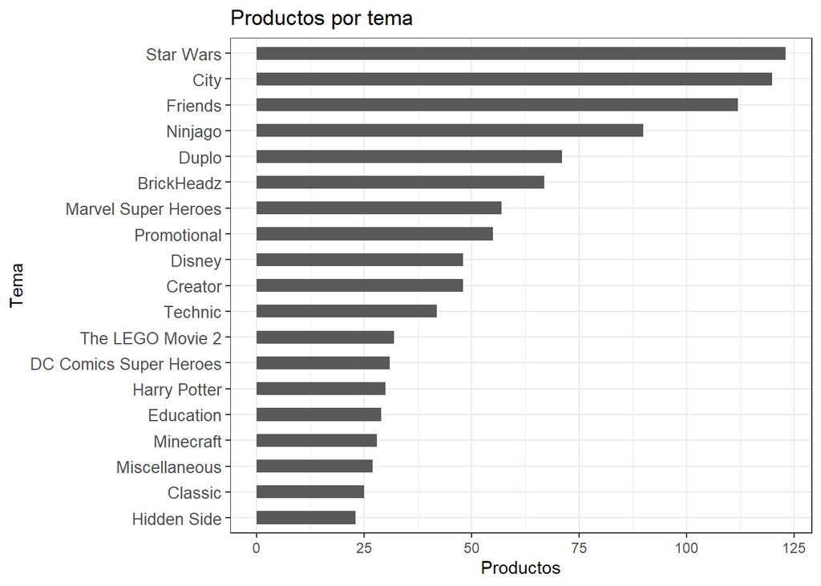

```r
tableTematicas <- tableTematicas %>%
  filter(N > 20)

ggplot(tableTematicas, aes( x = fct_reorder(Theme, N), y = N)) +
  geom_col(width = 0.5, group = 1) +
  scale_fill_viridis_c() +
  coord_flip() +
  labs(x = 'Tema', y = 'Productos', title = 'Productos por tema') +
  theme_bw() +
  theme(axis.text.y = element_text(size = 10))
```

### 3.2 Por Tema y Edad

El primer análisis muestra para cada Tema las posibles edades target.

```r
tableTematicas <- unique(datosReduced[ , .(.N), by = .(Theme, Ages)])
setorder(tableTematicas, Theme, -N, Ages )
tableTematicas
```

```
##                  Theme   Ages     N
##                 <fctr> <fctr> <int>
##   1:      Architecture    16+    11
##   2:      Architecture    12+     1
##   3:      Architecture    18+     1
##   4:               Art    18+     4
##   5:    Brick Sketches     8+     4
##  ---
## 159: Trolls World Tour     5+     1
## 160:          Unikitty     5+     5
## 161:          Unikitty     6+     3
## 162:          Unikitty     7+     1
## 163:              Xtra     6+     9
```

Para no centrarnos en los más vendidos, a continuación se procede a estudiar dos temas populares pero de naturaleza muy distinta: **Marvel Super Heroes** y **Technic**

```
## $`1`
```

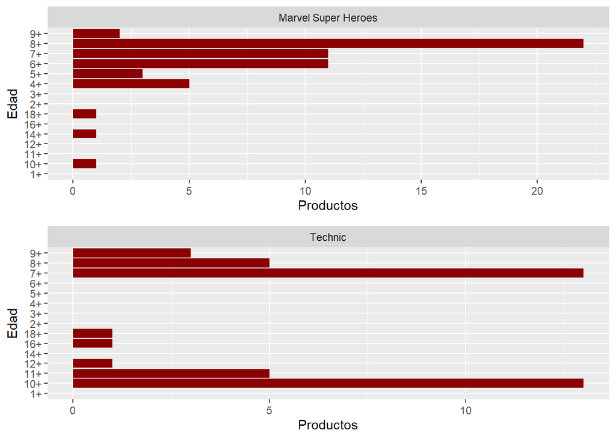

```
##
## $`2`
```

```
##
## attr(,"class")
## [1] "list"      "ggarrange"
```

```r
marvelTech <- datosReduced[Theme == 'Marvel Super Heroes' | Theme == 'Technic', ]

marvelTech_freq <- unique(marvelTech[ , .(.N), by = .(Theme, Ages)])

marvelTech_freq <- setorder(marvelTech_freq, Theme, -N, Ages)

marvel <-  ggplot(marvelTech_freq[Theme == 'Marvel Super Heroes'], aes( x = fct_reorder(Ages, N ), y = N)) +
  geom_col(group = 1, fill = 'darkred') +
  coord_flip() +
  facet_wrap( ~ Theme ) +
  labs(x = 'Edad', y = 'Productos') +
   # Establecer el mismo límite en el eje x
  xlim(levels(marvelTech_freq$Ages))

technic <-  ggplot(marvelTech_freq[Theme == 'Technic'], aes( x = fct_reorder(Ages, N ), y = N)) +
  geom_col(group = 1, fill = 'darkred') +
  coord_flip() +
  facet_wrap( ~ Theme ) +
  labs(x = 'Edad', y = 'Productos') +
   # Establecer el mismo límite en el eje x
  xlim(levels(marvelTech_freq$Ages))

combined_plot <- ggarrange(marvel, technic, nrow = 2, common.legend = TRUE, legend = "bottom",
                           title = "Productos por temática y edad target")

print(combined_plot)
```

### 3.3 Por Tema, Edad y Año

Para tener una idea de qué cuántos productos se han vendido cada año para cada tema y según qué edad target, graficamos la frecuencia.

[figure not shown]

```r
marvelTechYear_freq <- unique(marvelTech[ , .(.N), by = .(Theme, Ages, Year)])

setorder(marvelTechYear_freq, Theme, -N, Ages, Year)

marvelYear <-  ggplot(marvelTechYear_freq[ Theme == 'Marvel Super Heroes'], aes( x = fct_reorder(Ages, N ), y = N)) +
  geom_col(group = 1, fill = 'darkred') +
  coord_flip() +
  facet_wrap( ~ Theme + Year ) +
  labs(x = 'Edad', y = 'Productos') +
  theme_bw() +
  # Establecer el mismo límite en el eje x
  xlim(levels(marvelTech_freq$Ages))
techYear <-  ggplot(marvelTechYear_freq[ Theme == 'Technic'], aes( x = fct_reorder(Ages, N ), y = N)) +
  geom_col(group = 1, fill = 'darkred') +
  coord_flip() +
  facet_wrap( ~ Theme + Year ) +
  labs( x = 'Edad', y = 'Productos') +
  theme_bw() +
  # Establecer el mismo límite en el eje x
  xlim(levels(marvelTech_freq$Ages))
marvelYear + techYear + plot_annotation(title = "Alquileres por distrito, barrio y tipo habitación")
```

### 3.4 Por Tema y Número de piezas

Lo primero es ver cómo varía el número de piezas en todo el conjunto del dataset.

```r
summary(datosReduced$Pieces)
```

```
##    Min. 1st Qu.  Median    Mean 3rd Qu.    Max.
##    1.00   71.25  193.00  396.00  454.00 9036.00
```

Se observa que hay juguetes de 1 pieza hasta de 9036 piezas.

```r
summary(marvelTech$Pieces)
```

```
##    Min. 1st Qu.  Median    Mean 3rd Qu.    Max.
##    32.0   165.0   358.0   656.2   692.0  4108.0
```

```r
# creo los intervalos
custom_breaks <- c(1, 500, 1000, 1500, 2000, 2500, 3000, 3500, 4000, 4500)

# creo una nueva variable en el dataset con esos intervalos
marvelTech$Intervalo_Piezas <- cut(marvelTech$Pieces, breaks = custom_breaks, include.lowest = TRUE, labels = paste0("[", custom_breaks[-length(custom_breaks)], ", ", custom_breaks[-1], "]"))
# head(marvelTech)
```

```r
# creo una tabla de frecuencia
tableTematicasPiezas_freq <- unique(marvelTech[ , .(.N), by = .(Theme, Intervalo_Piezas)])
tableTematicasPiezas_freq
```

```
##                   Theme Intervalo_Piezas     N
##                  <fctr>           <fctr> <int>
##  1: Marvel Super Heroes         [1, 500]    46
##  2:             Technic         [1, 500]    17
##  3:             Technic      [500, 1000]     8
##  4:             Technic     [1000, 1500]     7
##  5:             Technic     [2500, 3000]     2
##  6:             Technic     [4000, 4500]     2
##  7:             Technic     [3500, 4000]     2
##  8:             Technic     [1500, 2000]     2
##  9:             Technic     [2000, 2500]     2
## 10: Marvel Super Heroes     [1000, 1500]     3
## 11: Marvel Super Heroes      [500, 1000]     8
```

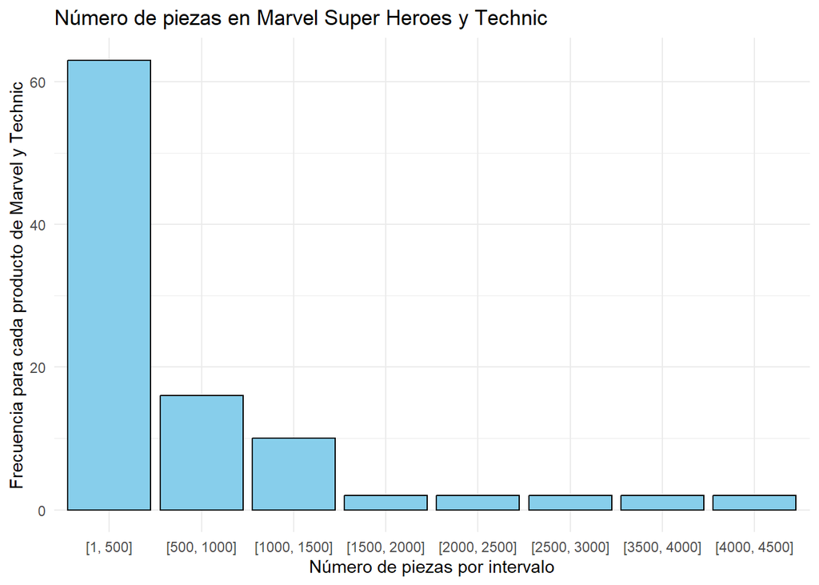

```r
# primero grafico todo junto en el conjunto reducido de Marvel y Technic
ggplot(marvelTech, aes(x = Intervalo_Piezas)) +
  geom_bar(fill = "skyblue", color = "black") +
  labs(x = "Número de piezas por intervalo", y = "Frecuencia para cada producto de Marvel y Technic", title = "Número de piezas en Marvel Super Heroes y Technic") +
  theme_minimal()
```

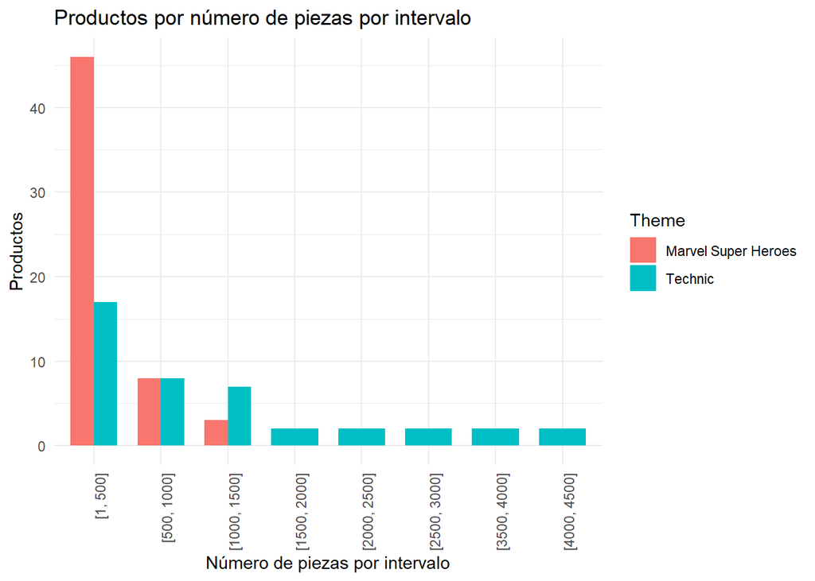

```r
# luego grafico la diferencia entre Marvel Super Heroes y Technic
ggplot(tableTematicasPiezas_freq, aes(x = Intervalo_Piezas, y = N, fill = Theme)) +
  geom_col(position = "dodge", width = 0.7) +
  labs(x = "Número de piezas por intervalo", y = "Productos", title = "Productos por número de piezas por intervalo") +
  theme_minimal() +
  theme(legend.position = "right", axis.text.x = element_text(angle = 90, hjust = 1))
```

Como se puede ver de la grafica anterior, para el tema **Marvel Super Heros** hay mayoritariamente juguetes de entre 1 y 1500 piezas; mientras que para el tema **Technic** parece ser que los juguetes requieren más nivel de competencia, teniendo en cuenta que pueden llegar a las 4000 piezas.

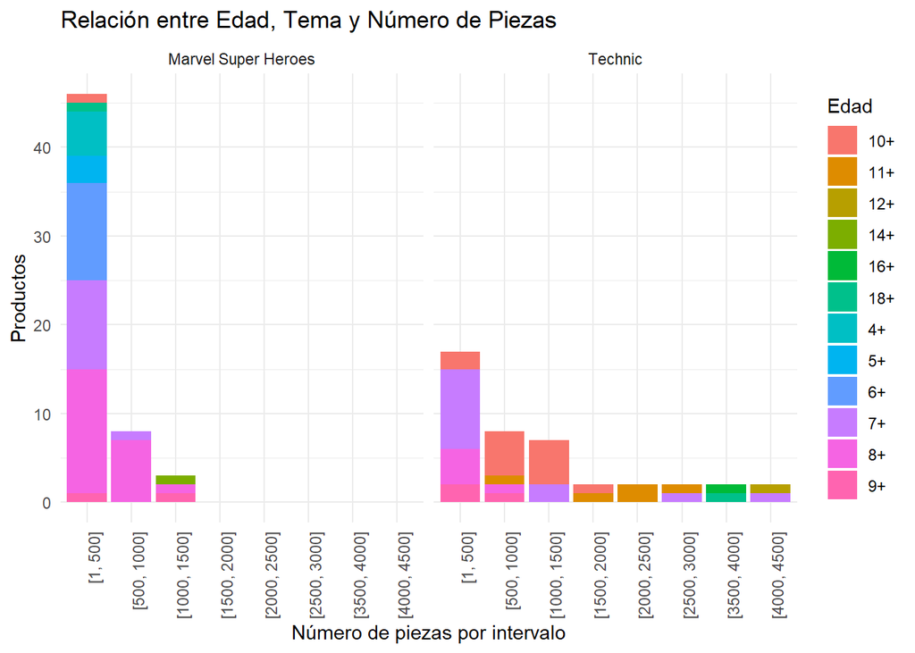

```r
# grafico la relación entre las variables categóricas Theme y Ages con la variable numérica discreta con intervalos Pieces
ggplot(marvelTech, aes(x = Intervalo_Piezas, fill = Ages)) +
  geom_bar(position = "stack") +
  facet_wrap(~ Theme) +
  labs(x = "Número de piezas por intervalo", y = "Productos", fill = "Edad", title = "Relación entre Edad, Tema y Número de Piezas") +
  theme_minimal()+
  theme(legend.position = "right", axis.text.x = element_text(angle = 90, hjust = 1))
```

El gráfico anterior confirma que la mayor parte de los juguetes de 1 a 500 piezas están destinados mayoritariamente a personas con edades inferiores a 10 años tanto para **Marvel Super Heros** como para **Technic**.

```r
# Crear la tabla bivariante de frecuencias
bivariate_table <- table(marvelTech$Intervalo_Piezas, marvelTech$Ages)

# Mostrar la tabla
formattable(bivariate_table)
```

```
##
##                1+ 10+ 11+ 12+ 14+ 16+ 18+ 2+ 3+ 4+ 5+ 6+ 7+ 8+ 9+
##   [1, 500]      0  3   0   0   0   0   1   0  0  5  3 11 19 18  3
##   [500, 1000]   0  5   1   0   0   0   0   0  0  0  0  0  1  8  1
##   [1000, 1500]  0  5   0   0   1   0   0   0  0  0  0  0  2  1  1
##   [1500, 2000]  0  1   1   0   0   0   0   0  0  0  0  0  0  0  0
##   [2000, 2500]  0  0   2   0   0   0   0   0  0  0  0  0  0  0  0
##   [2500, 3000]  0  0   1   0   0   0   0   0  0  0  0  0  1  0  0
##   [3000, 3500]  0  0   0   0   0   0   0   0  0  0  0  0  0  0  0
##   [3500, 4000]  0  0   0   0   0   1   1   0  0  0  0  0  0  0  0
##   [4000, 4500]  0  0   0   1   0   0   0   0  0  0  0  0  1  0  0
```

### 3.5 Por Disponibilidad

A continuación se presenta un análisis de frecuencia de la variable Disponibilidad.

```r
tableAvailability <-datosReduced[ ,.N, by = "Availability"]
setorder(tableAvailability, -N)
tableAvailability
```

```
##          Availability     N
##                <fctr> <int>
## 1:             Retail   989
## 2:     LEGO exclusive   168
## 3:   Retail - limited   103
## 4:           Not sold    28
## 5:        Educational    18
## 6:        Promotional    18
## 7: LEGOLAND exclusive     6
```

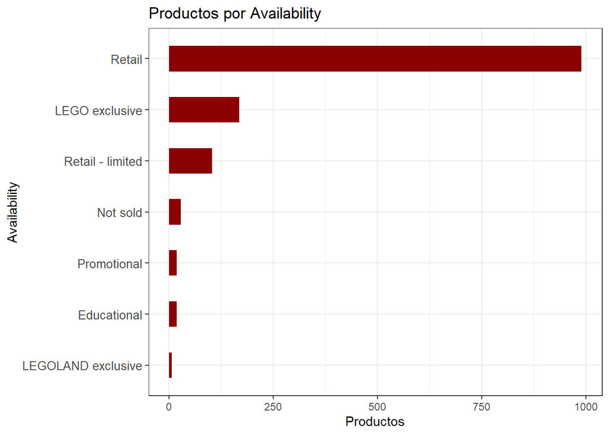

```r
ggplot(tableAvailability, aes( x = fct_reorder(Availability, N), y = N)) +
  geom_col(width = 0.5, group = 1, fill = 'darkred') +
  coord_flip() +
  labs(x = 'Availability', y = 'Productos', title = 'Productos por Availability') +
  theme_bw() +
  theme(axis.text.y = element_text(angle = 0, size = 10))
```

Se observa que Retail es la mayor opción para disponibilidad de los juguetes.

## 4. Relaciones Bivariantes

[figure not shown]

```r
marvelTechMinifigures_freq <- unique(marvelTech[ , .(.N), by = .(Theme, Minifigures, Pieces)])

marvelTechMinifigures_freq <- setorder(marvelTechMinifigures_freq, Theme, -N, Minifigures, Pieces)

ggplot(marvelTechMinifigures_freq, aes( x = Minifigures, y = Pieces, color = Theme)) +
  geom_point(size = 2, aes(shape = Theme)) +
  labs(title = "Relación entre piezas y número de piezas únicas",
       x = "Número de piezas únicas",
       y = "Piezas") +
  theme_void() +  # Remove all default theme elements
  theme(
    axis.text = element_text(color = "black", size = 8),  # Black axis text (adjust size)
    axis.title = element_text(color = "black", size = 8),  # Black axis titles (adjust size)
  ) +
  theme(panel.grid.major = element_line(color = "lightgray", linetype = "dashed"))
```

### 4.2 Por Año

El primer análisis que se presenta es sobre todo el conjunto de datos.

```r
setDT(datosReduced)
tablaAnio <-unique(datosReduced[ ,.N, by = Year])
head(tablaAnio,5)
```

```
##      Year     N
##    <fctr> <int>
## 1:   2018   446
## 2:   2019   426
## 3:   2020   458
```

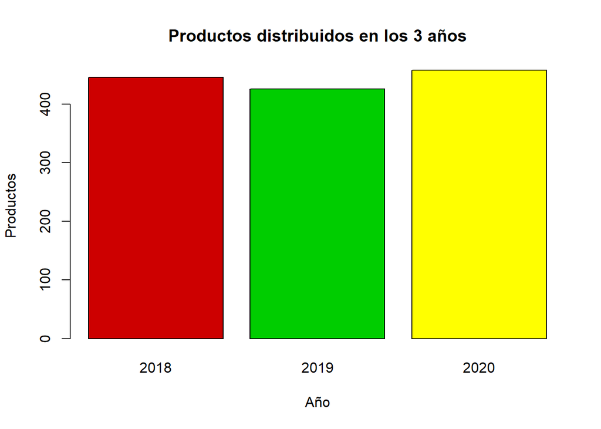

```r
barplot(tablaAnio$N, col=c("red3","green3", "yellow"), names.arg = tablaAnio$Year,
        xlab="Año", ylab="Productos",
        main="Productos distribuidos en los 3 años")
```

En general, se observa que no hay mucha diferencia de ventas entre los tres años.

```r
setDT(datosReduced)
tablaAnioPack <-unique(datosReduced[ ,.N, by = .(Year, Packaging)])
head(tablaAnioPack,5)
```

```
##      Year      Packaging     N
##    <fctr>         <fctr> <int>
## 1:   2018            Box   372
## 2:   2019            Box   354
## 3:   2020            Box   362
## 4:   2018    Plastic box     4
## 5:   2018 Shrink-wrapped     1
```

### 4.3. Por Año y por Empaquetado

Luego, se procede a un análisis para ver el uso del empaquetado según el año, teniendo en cuenta que puede influir factores externos en la opción del packaging (por ejemplo, temas de cuidado del medioambiente).

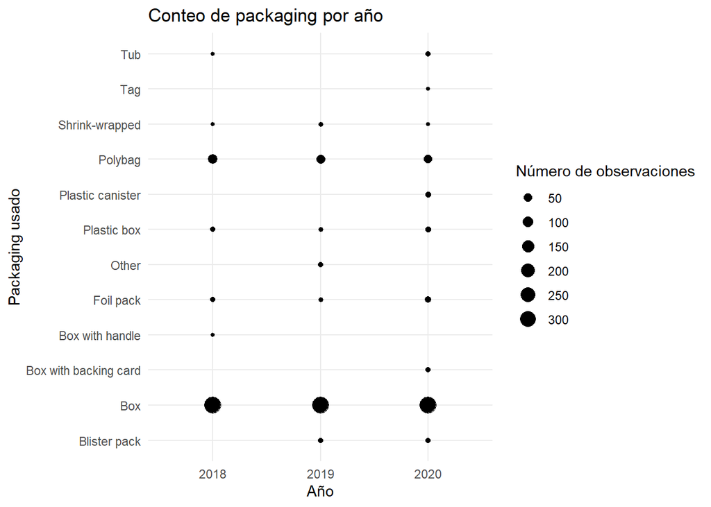

```r
datosReduced %>%
  ggplot(aes(x = Year, y = Packaging)) +
  geom_count() +
  scale_size_continuous(name = "Número de observaciones", limits = c(1, 500), breaks = c(50, 100, 150, 200, 250, 300)) +
  scale_fill_gradient(low = "grey", high = "red") +  # Map color to size for continuous gradient
  labs(x = "Año", y = "Packaging usado", title = "Conteo de packaging por año") +
  theme_minimal()
```

Se puede observar que las cajas siguen siendo la opción más elegida a lo largo del intervalo temporal elegido. También hay que tener en cuenta que las caja de LEGO están hechas por cartón reciclado, por lo tanto, puede seguir siendo la opción favorita.

### 4.3 Por Piezas y Peso

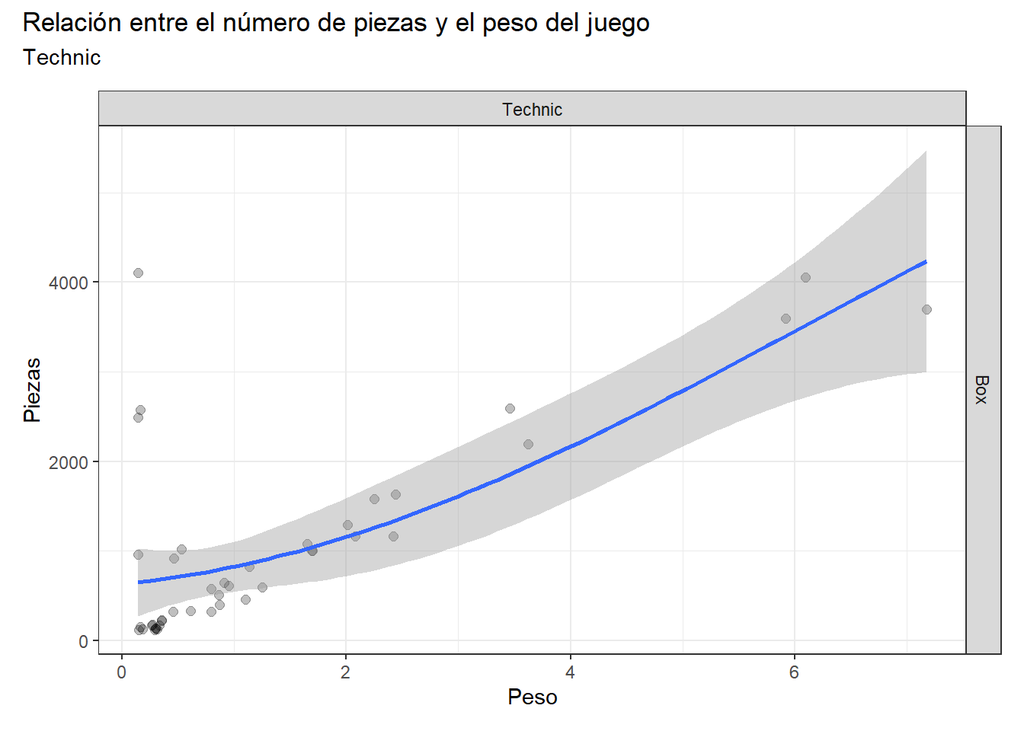

```r
# Ya tenemos el data.frame construido "chamciudroom" del análisis anterior.
# Vemos la relación entre precio y number_of_reivews
TechWeight <-  ggplot(marvelTech[ Theme == 'Technic', ], aes( x = Weight, y = Pieces)) +
  geom_point(fill = 'darkred', alpha = 0.25, size = 2) +
  geom_smooth(span = 2) +
  facet_grid(  Packaging ~ Theme, scales = 'free' ) +
  labs(x = 'Peso', y = 'Piezas') +
  theme_bw()
TechWeight + plot_annotation(title = "Relación entre el número de piezas y el peso del juego",
                                subtitle = 'Technic')
```

Se puede observar una tendencia de relación lineal, aunque hay algunos outliers.

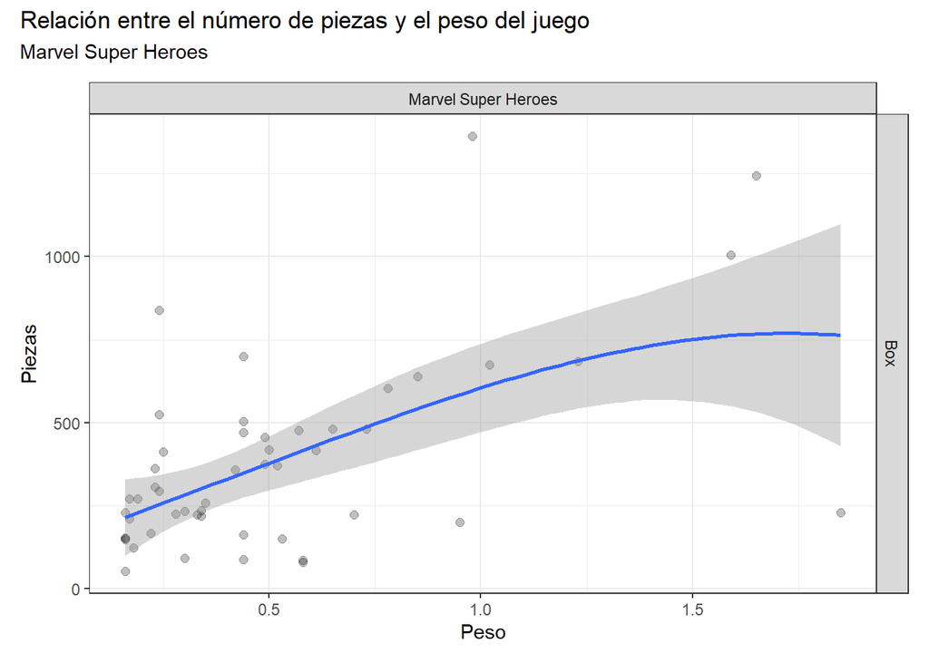

```r
# Ya tenemos el data.frame construido "chamciudroom" del análisis anterior.
# Vemos la relación entre precio y number_of_reivews
marvelWeight <-  ggplot(marvelTech[ Theme == 'Marvel Super Heroes' & Packaging == "Box", ], aes( x = Weight, y = Pieces)) +
  geom_point(fill = 'darkred', alpha = 0.25, size = 2) +
  geom_smooth(span = 2) +
  facet_grid(  Packaging ~ Theme, scales = 'free' ) +
  labs(x = 'Peso', y = 'Piezas') +
  theme_bw()

marvelWeight + plot_annotation(title = "Relación entre el número de piezas y el peso del juego",
                                subtitle = 'Marvel Super Heroes')
```

Se puede ver que para el tema **Marvel** hay más outliers, que sería interesante investigar: seguramente entrando en detalle sobre el juego (`Set_Name`).

## 5. Correlación

Se calcula la correlación entre las variables del número de piezas y el peso.

```r
# calculo la correlación de Pearson
correlation <- cor(datosReduced$Pieces, datosReduced$Weight, method = "pearson")
print(correlation)
```

```
## [1] 0.4673625
```

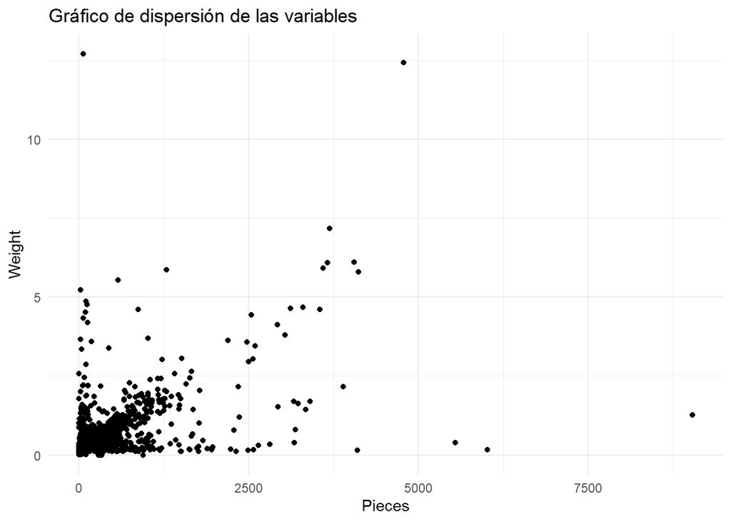

```r
ggplot(datosReduced, aes(x = Pieces, y = Weight)) +
  geom_point() +
  labs(x = "Pieces", y = "Weight", title = "Gráfico de dispersión de las variables") +
  theme_minimal()
```